title: “Homework-week-4_2” author: “Maria C. Codlin” date: “September 27, 2017” output: html_document —

```r
library(curl)
library(dplyr)
```

```r
library(ggplot2)
library(reshape2)
library(manipulate)
library(qwraps2)
options(qwraps2_markup="markdown")
f <- f <- curl("https://raw.githubusercontent.com/fuzzyatelin/fuzzyatelin.github.io/master/AN597_Fall17/zombies.csv")
d <- read.csv(f, header = TRUE, sep = ",", stringsAsFactors = FALSE)
head(d)
```

```
##   id first_name last_name gender   height   weight zombies_killed
## 1  1      Sarah    Little Female 62.88951 132.0872              2
## 2  2       Mark    Duncan   Male 67.80277 146.3753              5
## 3  3    Brandon     Perez   Male 72.12908 152.9370              1
## 4  4      Roger   Coleman   Male 66.78484 129.7418              5
## 5  5      Tammy    Powell Female 64.71832 132.4265              4
## 6  6    Anthony     Green   Male 71.24326 152.5246              1
##   years_of_education                           major      age
## 1                  1                medicine/nursing 17.64275
## 2                  3 criminal justice administration 22.58951
## 3                  1                       education 21.91276
## 4                  6                  energy studies 18.19058
## 5                  3                       logistics 21.10399
## 6                  4                  energy studies 21.48355
```

```r
d<-tbl_df(d)
```

**[1] Calculate the population mean and standard deviation for each quantitative random variable (height, weight, age, number of zombies killed, and years of education). NOTE: You will not want to use the built in var() and sd() commands as these are for samples.**

```r
#Here I am setting up the functions for the population standard deviation
pop_v <- function(x) {
    sum((x - mean(x))^2)/(length(x))
}
pop_sd <- function(x) {
    sqrt(pop_v(x))
}

pop_means<-summarize_all(select(d, height:zombies_killed, years_of_education, age), funs(mean, pop_sd))
pop_means
```

```
## # A tibble: 1 x 10
##   height_mean weight_mean zombies_killed_mean years_of_education_mean
##         <dbl>       <dbl>               <dbl>                   <dbl>
## 1     67.6301    143.9075               2.992                   2.996
## # ... with 6 more variables: age_mean <dbl>, height_pop_sd <dbl>,
## #   weight_pop_sd <dbl>, zombies_killed_pop_sd <dbl>,
## #   years_of_education_pop_sd <dbl>, age_pop_sd <dbl>
```

**[2] Use {ggplot} and make boxplots of each of these variables by gender.**

```r
#convert gender to factor
d$gender<-as.factor(d$gender)
#to put multiple columns on one bar graph, melt the data and remove NAs (reshape2 package)
var.m<- melt(data=(select(d, height:zombies_killed, years_of_education, age, gender)), na.rm=TRUE)
head(var.m)
```

```
##   gender variable    value
## 1 Female   height 62.88951
## 2   Male   height 67.80277
## 3   Male   height 72.12908
## 4   Male   height 66.78484
## 5 Female   height 64.71832
## 6   Male   height 71.24326
```

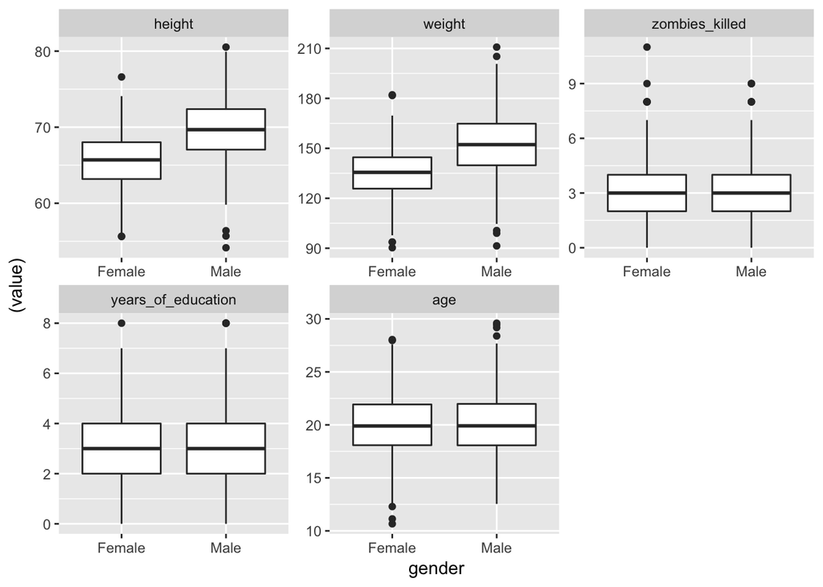

```r
p<-ggplot(data=var.m, aes(x=gender, y=(value)))
p+geom_boxplot()+facet_wrap(~variable, scales="free")
```

**[3] Use {ggplot} and make scatterplots of height and weight in relation to age. Do these variables seem to be related? In what way?**

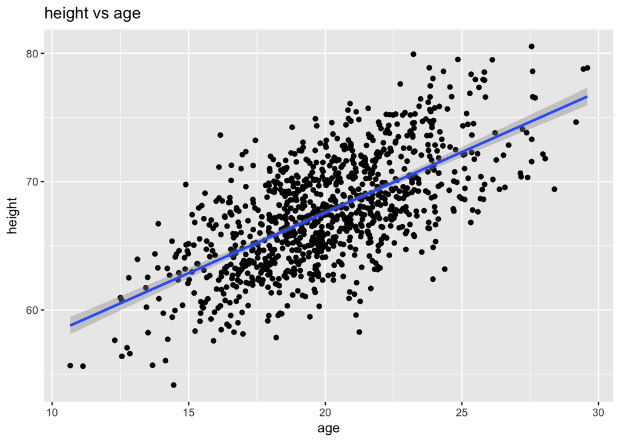

```r
scat<-ggplot(data=d, aes(x=age, y=height))+geom_point()+geom_smooth(method=lm)+labs(title="height vs age")
scat2<-ggplot(data=d, aes(x=age, y=weight))+geom_point()+geom_smooth(method=lm)+labs(title="weight vs age")
scat
```

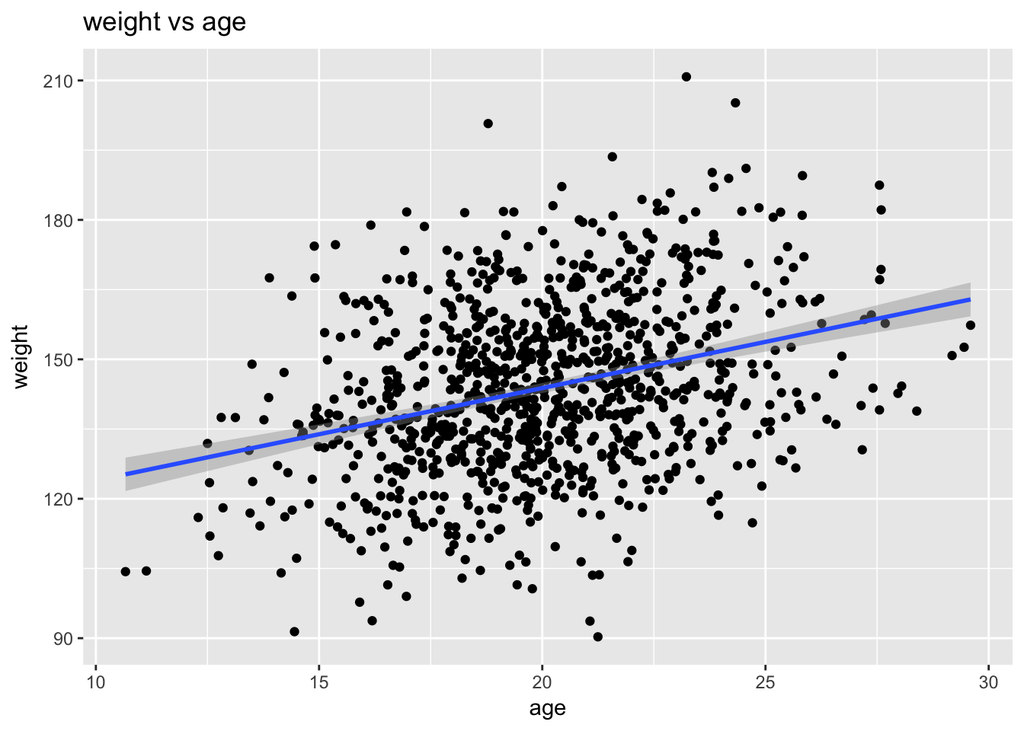

```r
scat2
```

**[4] Using histograms and Q-Q plots, check whether the quantitative variables seem to be drawn from a normal distribution. Which seem to be and which do not (hint: not all are drawn from the normal distribution)? For those that are not, can you determine what common distribution they are drawn from?**

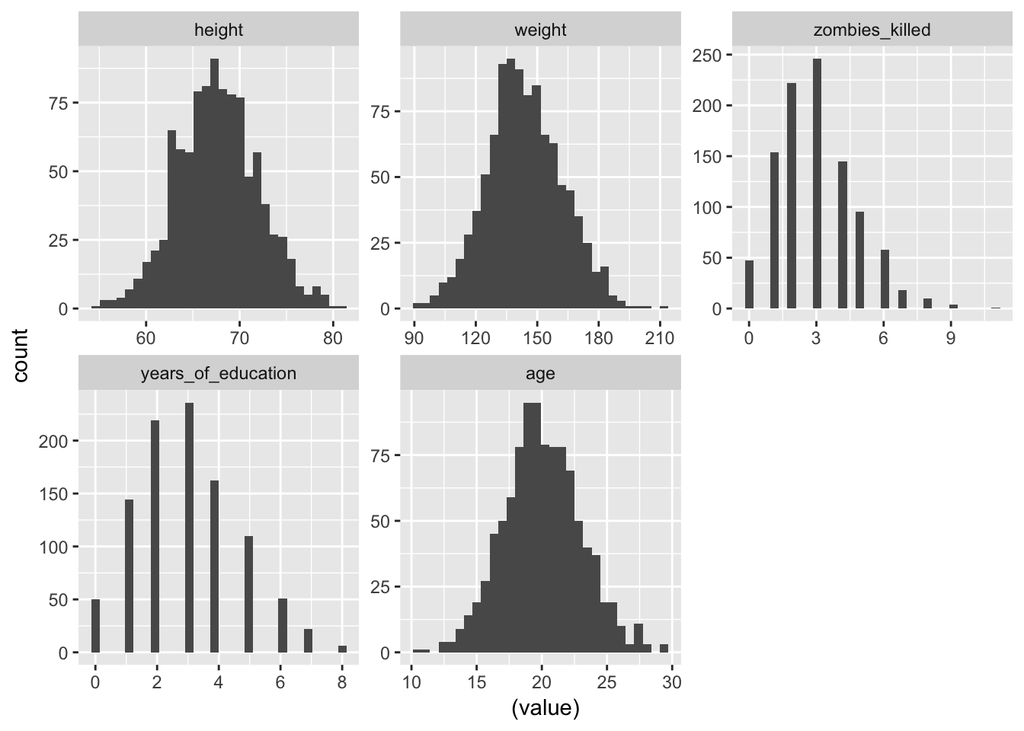

```r
hisQ<-ggplot(data=var.m, aes(x=(value)))
hisQ+geom_histogram()+facet_wrap(~variable, scales="free")
```

```r
var.m.g<-group_by(var.m, variable)
data(var.m.g)
```

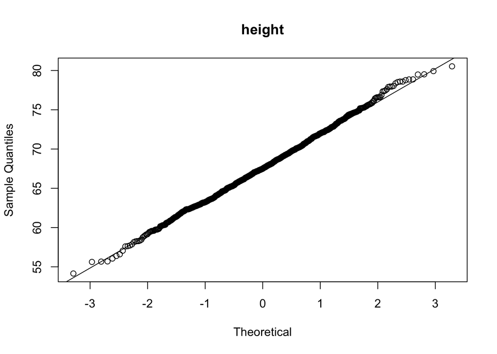

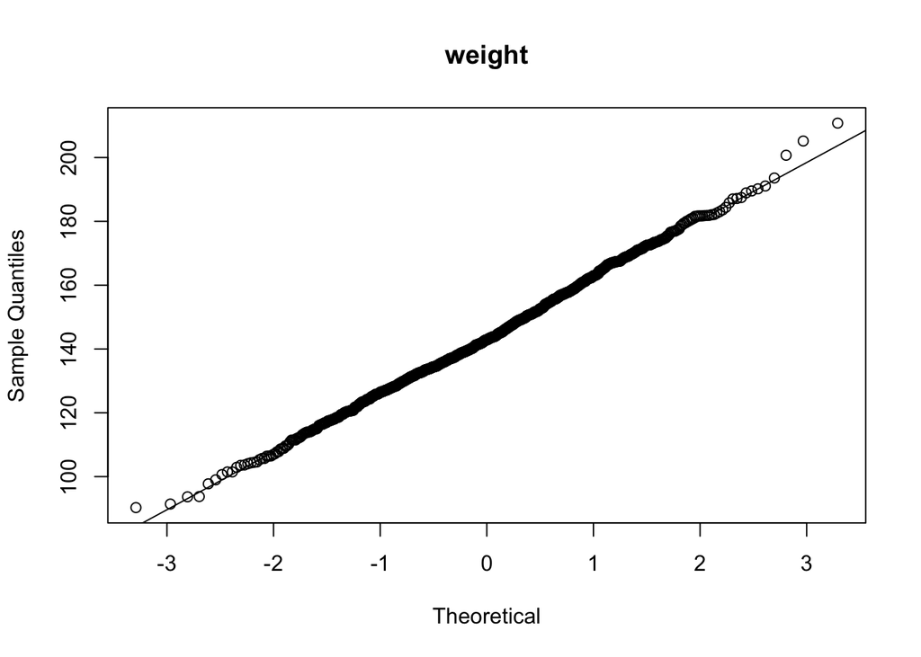

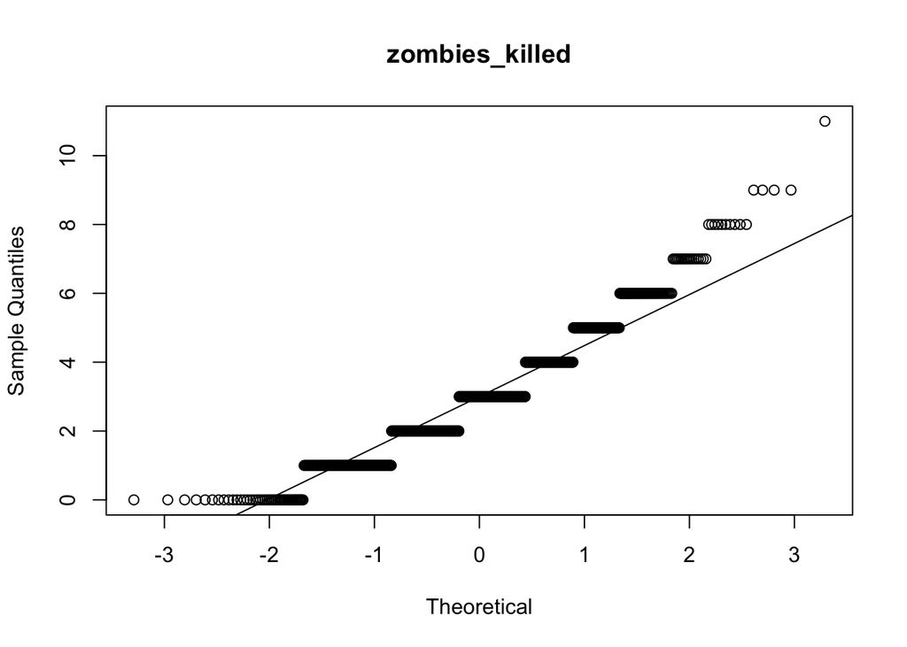

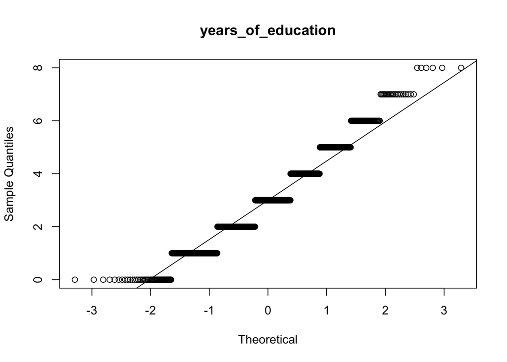

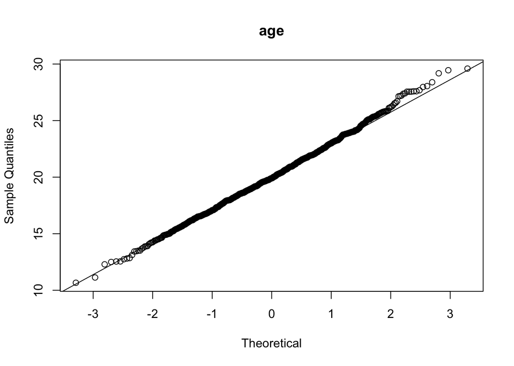

```r
#found code at https://stackoverflow.com/questions/20781663/qqnorm-plotting-for-multiple-subsets
for(i in levels(var.m.g$variable)){
  tmp <- with(var.m.g, value[variable==i])
  qqnorm(tmp,xlab="Theoretical",main=i)
  qqline(tmp)
}
```

```r
rm(i,tmp)
#Here I decided not to use par to line them up neatly as they were too small to clearly see the trends
```

Height and weight both appear to follow a normal distribution as the shape of the histograms and the qq plots fit nicely with what we would expect to see with a normal distribution, particularly that the majority of the points fall on the qqline shown in the qqplot. Age also appears to match this distribution, although it is a little more variable towards the upper part of the line. While age is not usually a variable that is normally distributed, here, age was calculated as continuous data and the distribution of this population was impacted by a zombie apocalypse, so I think it is fair to call it normally distributed based on how well it matches in the qqplot. The years of education and number of zombies killed are count data and look like they should match a poisson distribution.

**[5] Now use the sample() function to sample ONE subset of 30 zombie survivors (without replacement) from this population and calculate the mean and sample standard deviation for each variable. Also estimate the standard error for each variable and construct the 95% confidence interval for each mean. Note that for the variables that are not drawn from the normal distribution, you will need to base your estimate of the CIs on some different distribution.**

First I create a sample from the population called “s”

```r
s<-sample_n (d, size=30, replace=FALSE) #the sample function was obscured by dplyr, so I used the dplyr equiv.
head(s)
```

```
## # A tibble: 6 x 10
##      id first_name last_name gender   height   weight zombies_killed
##   <int>      <chr>     <chr> <fctr>    <dbl>    <dbl>          <int>
## 1   522   Patricia     Brown Female 67.49037 148.9743              3
## 2   967   Virginia      Webb Female 68.70509 151.2717              4
## 3   268    Michael      Cook   Male 61.62814 119.0915              3
## 4   228     Judith  Gonzalez Female 64.50872 124.1080              1
## 5   839       Ryan    Barnes   Male 68.23992 128.3578              2
## 6   885      Janet     Ellis Female 65.84293 130.1845              1
## # ... with 3 more variables: years_of_education <int>, major <chr>,
## #   age <dbl>
```

Then I create a function for calculating the confidence interval of normally distributed data.

```r
normalCI = function(x, CIlevel = 0.95) {
    upper = round(mean(x) + qnorm(1 - (1 - CIlevel)/2) * sqrt(var(x)/length(x)), 2)
    lower = round(mean(x) + qnorm((1 - CIlevel)/2) * sqrt(var(x)/length(x)), 2)
    ci <-
    ci<-toString(c(lower,"-",upper)) #add as string to fit in function above
    ci<-(gsub(",","",ci))
    return(ci)
}
```

Then I create a function to summarize the normally distributed data

```r
sum_stat=function(x){
summarize(s, "Mean"=round(mean(x, na.rm=TRUE), 2), "SD"=round(sd(x, na.rm=TRUE), 2), "SE"=round(sd(x)/sqrt(length(x)), 2), "confidence interval"=normalCI(x))
}
```

And run this for each normally distributed variable

```r
Height<-sum_stat(s$height)
Weight<-sum_stat(s$weight)
Age<-sum_stat(s$age)

Height
```

```
## # A tibble: 1 x 4
##    Mean    SD    SE `confidence interval`
##   <dbl> <dbl> <dbl>                 <chr>
## 1 67.91  3.79  0.69         66.55 - 69.27
```

```r
Weight
```

```
## # A tibble: 1 x 4
##     Mean    SD    SE `confidence interval`
##    <dbl> <dbl> <dbl>                 <chr>
## 1 140.95 17.31  3.16       134.76 - 147.14
```

```r
Age
```

```
## # A tibble: 1 x 4
##    Mean    SD    SE `confidence interval`
##   <dbl> <dbl> <dbl>                 <chr>
## 1 20.26  2.83  0.52         19.24 - 21.27
```

Next I failed miserably to figure out how to calculate the confidence interval for poisson distributed data by hand and decide to use a built-in function poisson.test instead.

```r
sum_stat_p=function(x){
s2<-summarize(s, "Mean"=round(mean(x, na.rm=TRUE), 2), "SD"=round(sd(x, na.rm=TRUE), 2), "SE"=round(sqrt(mean(x)/length(x)), 2))
s3<-poisson.test(sum(x), T=length(x))
return(list(s2,s3))
}
```

```r
"Zombies killed"<-sum_stat_p(s$zombies_killed)
"years of education"<-sum_stat_p(s$years_of_education)
`Zombies killed`
```

```
## [[1]]
## # A tibble: 1 x 3
##    Mean    SD    SE
##   <dbl> <dbl> <dbl>
## 1  2.83  1.53  0.31
##
## [[2]]
##
##  Exact Poisson test
##
## data:  sum(x) time base: length(x)
## number of events = 85, time base = 30, p-value < 2.2e-16
## alternative hypothesis: true event rate is not equal to 1
## 95 percent confidence interval:
##  2.263166 3.503461
## sample estimates:
## event rate
##   2.833333
```

```r
`years of education`
```

```
## [[1]]
## # A tibble: 1 x 3
##    Mean    SD    SE
##   <dbl> <dbl> <dbl>
## 1   2.5  1.46  0.29
##
## [[2]]
##
##  Exact Poisson test
##
## data:  sum(x) time base: length(x)
## number of events = 75, time base = 30, p-value = 3.864e-12
## alternative hypothesis: true event rate is not equal to 1
## 95 percent confidence interval:
##  1.966409 3.133772
## sample estimates:
## event rate
##        2.5
```

**[6] Now draw 99 more random samples of 30 zombie survivors out and calculate the mean for each of the these samples. Together with the first sample you drew out, you now have a set of 100 means for each variable (each based on 30 observations), which constitutes a sampling distribution for each variable.**

```r
s_100<-NULL #set up the dummy
 for (i in 1:100) {
    s_100[[i]]  <-sample_n (d, size=30, replace=FALSE) #the sample function was obscured by dplyr, so I used the dplyr equiv.
 }
```

```r
m <- NULL
for (i in 1:100) {
    m$height[i] <- mean(s_100[[i]]$height)
    m$weight[i] <- mean(s_100[[i]]$weight)
    m$age[i] <- mean(s_100[[i]]$age)
    m$zombies_killed[i] <- mean(s_100[[i]]$zombies_killed)
    m$years_of_education[i] <- mean(s_100[[i]]$years_of_education)
}
```

**What are the means and standard deviations of this distribution for each variable?** I used lapply to apply means and sd across the sampling distrubution of each element

```r
sapply(m, mean)
```

```
##             height             weight                age
##          67.531596         143.671298          20.025349
##     zombies_killed years_of_education
##           2.999333           3.016667
```

```r
sapply(m, sd)
```

```
##             height             weight                age
##          0.7928056          3.5743576          0.4888905
##     zombies_killed years_of_education
##          0.3067874          0.2861761
```

**What do these sampling distributions look like? Are they normally distributed? What about for those variables that you concluded were not originally drawn from a normal distribution?**

```r
mm<-melt(m)
mm$L1<-as.factor(mm$L1)
str(mm)
```

```
## 'data.frame':    500 obs. of  2 variables:
##  $ value: num  66.4 68.9 65.7 68.4 68.2 ...
##  $ L1   : Factor w/ 5 levels "age","height",..: 2 2 2 2 2 2 2 2 2 2 ...
```

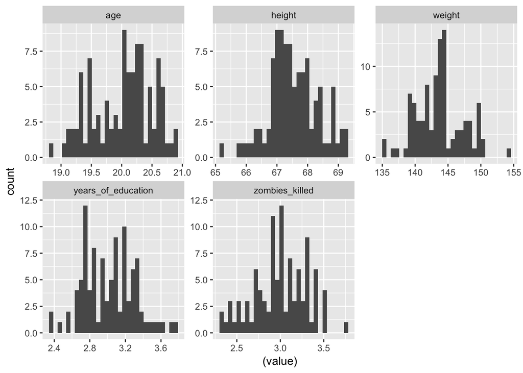

```r
hisQ_sample<-ggplot(data=mm, aes(x=(value)))
hisQ_sample+geom_histogram()+facet_wrap(~L1, scales="free")
```

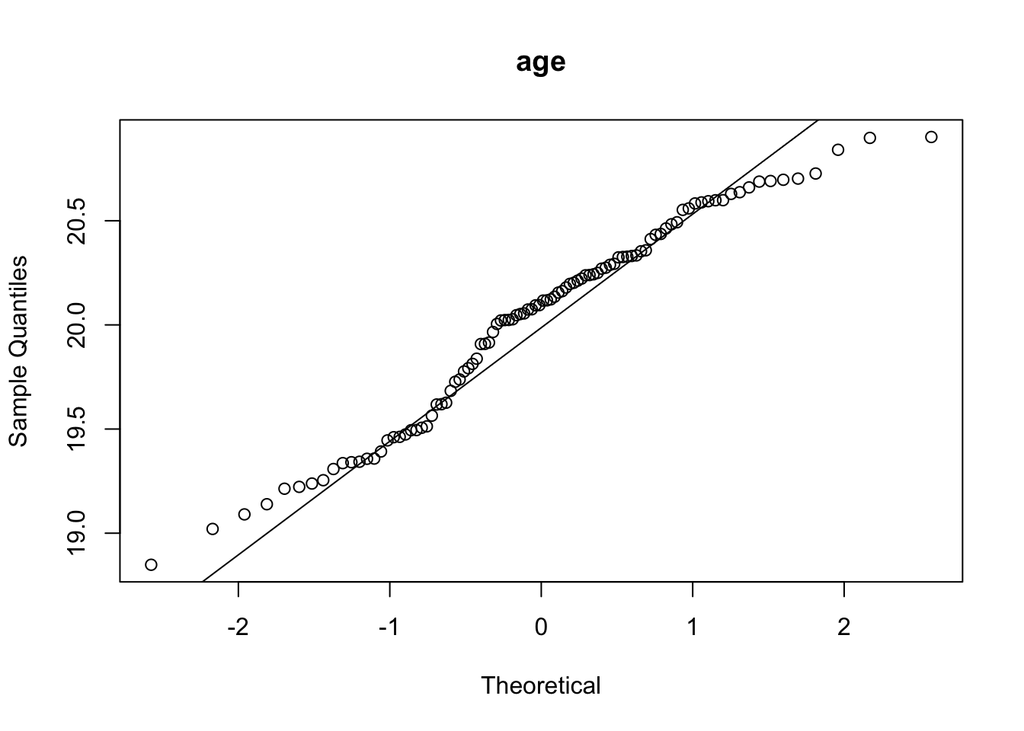

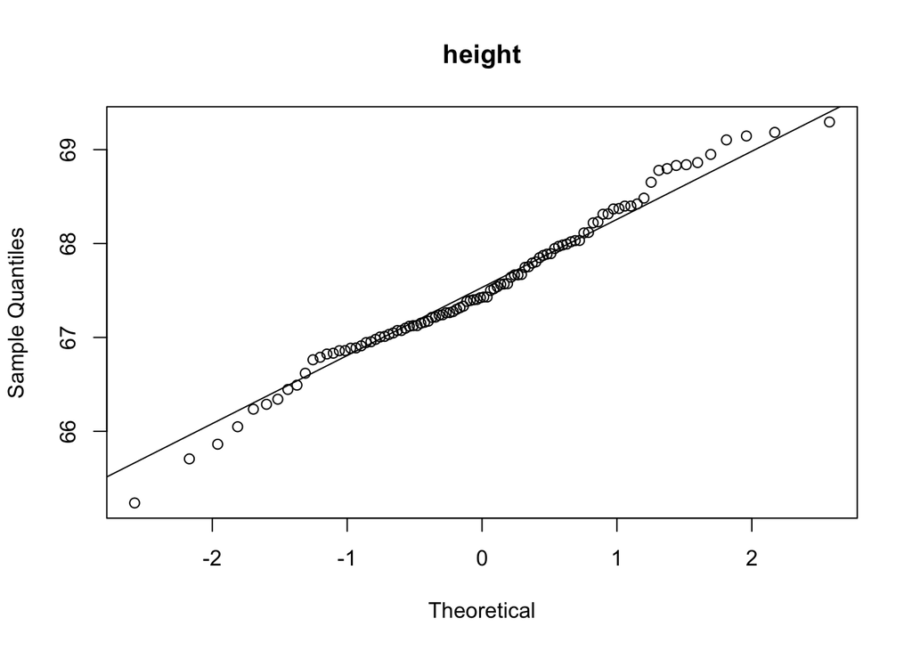

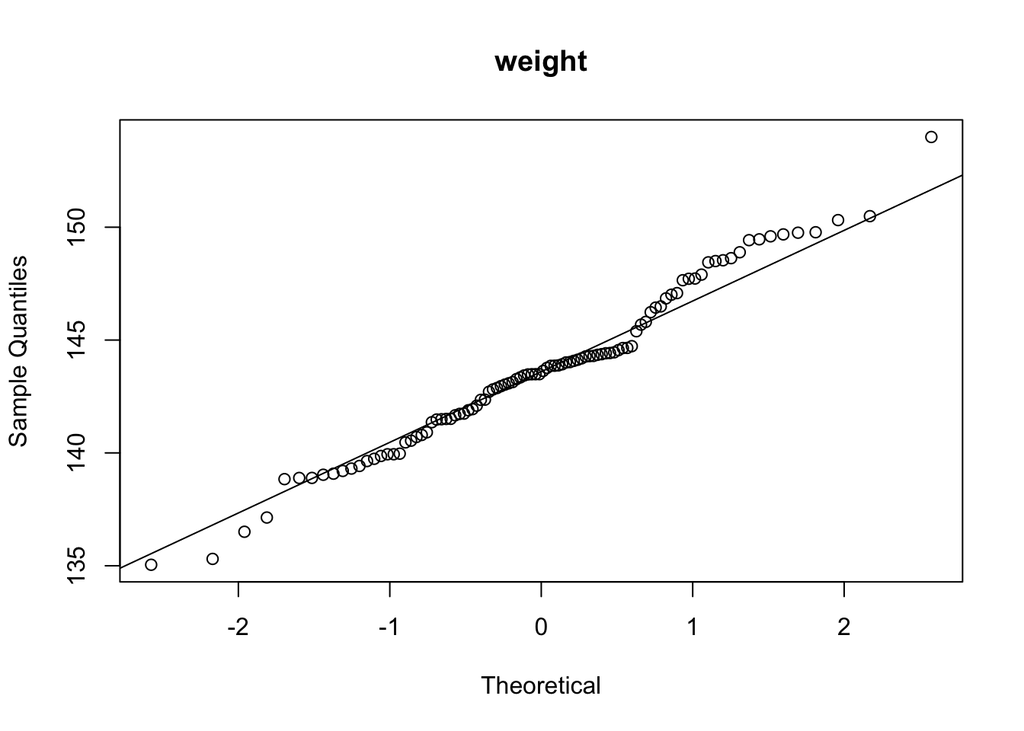

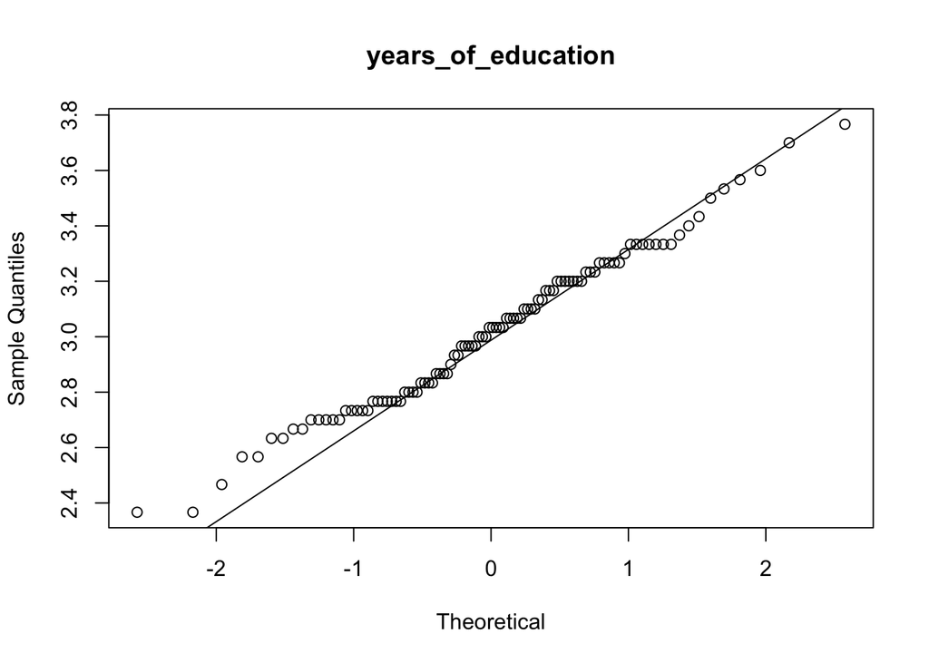

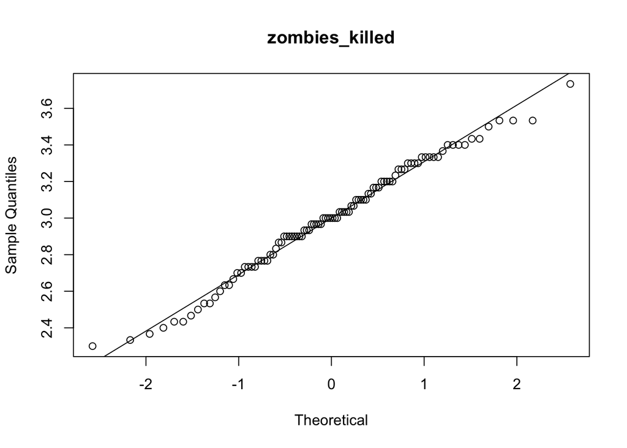

```r
#found code at https://stackoverflow.com/questions/20781663/qqnorm-plotting-for-multiple-subsets
for(i in levels(mm$L1)){
  tmp<- with(mm, value[L1==i])
  qqnorm(tmp,xlab="Theoretical",main=i)
  qqline(tmp)
}
```

```r
rm(i,tmp)
#Here I decided not to use par to line them up neatly as they were too small to clearly see the trends
```